# Weather Events with the Greatest Human Health and Financial Impacts

Chris Thatcher

February 22, 2015

**Synopsis**

> *While tornados clearly lead in fatalities, injuries and property damage, drought clearly has the greatest cost to crop producers.*

## Introduction

Storms and other severe weather events can cause both public health and economic problems for communities and municipalities. Many severe events can result in fatalities, injuries, and property damage, and preventing such outcomes to the extent possible is a key concern.

This project involves exploring the U.S. National Oceanic and Atmospheric Administration’s (NOAA) storm database. This database tracks characteristics of major storms and weather events in the United States, including when and where they occur, as well as estimates of any fatalities, injuries, and property damage.

*Note: Introduction taken verbatim from courera assignment.*

## Data

The data for this analysis comes in the form of a comma-separated-value file compressed via the bzip2 algorithm to reduce its size. We downloaded the file from the course web site:

[Storm Data](https://d396qusza40orc.cloudfront.net/repdata%2Fdata%2FStormData.csv.bz2) [47Mb]

There is also some documentation of the database available. Here you will find how some of the variables are constructed/defined.

[National Weather Service Storm Data Documentation](https://d396qusza40orc.cloudfront.net/repdata%2Fpeer2_doc%2Fpd01016005curr.pdf)

[National Climatic Data Center Storm Events FAQ](https://d396qusza40orc.cloudfront.net/repdata%2Fpeer2_doc%2FNCDC%20Storm%20Events-FAQ%20Page.pdf)

The events in the database start in the year 1950 and end in November 2011. In the earlier years of the database there are generally fewer events recorded, most likely due to a lack of good records. More recent years should be considered more complete.

*Note: Data section taken verbatim from courera assignment.*

In order to avoid duplicating the source data in our analysis repository, we check for it locally and only download it if it is not already available locally. The source data is ignored by our analysis repository.

```r
library(data.table)
DATA_URL = 'https://d396qusza40orc.cloudfront.net/repdata%2Fdata%2FStormData.csv.bz2'
DATA_FILE = 'data/StormData.csv.bz2'

# Make sure we have the data to work with locally, otherwise go get it.
if( !file.exists(DATA_FILE) ){

    message("Downloading data from url.")

    if("Windows" == Sys.info()["sysname"])
        download.file(DATA_URL, destfile=DATA_FILE)
    else
        download.file(DATA_URL, destfile=DATA_FILE, method="curl")

} else {
    message("Downloaded data found locally, not repeating.")
}
```

```
## Downloaded data found locally, not repeating.
```

## Data Processing

```r
storm_data = read.csv(DATA_FILE)
```

We are only interested in a few fields from the data set, in particular: * EVTYPE * FATALITIES * INJURIES * PROPDMG * PROPDMGEXP * CROPDMG * CROPDMGEXP

The following allows us to filter down the original data set into just the fields we want to analyze.

```r
columns = grep(
    'EVTYPE|FATALITIES|INJURIES|DMG',
    names(storm_data),
    perl=TRUE
)
features = as.data.table(storm_data[,columns])
str(features)
```

```
## Classes 'data.table' and 'data.frame':   902297 obs. of  7 variables:
##  $ EVTYPE    : Factor w/ 985 levels "   HIGH SURF ADVISORY",..: 834 834 834 834 834 834 834 834 834 834 ...
##  $ FATALITIES: num  0 0 0 0 0 0 0 0 1 0 ...
##  $ INJURIES  : num  15 0 2 2 2 6 1 0 14 0 ...
##  $ PROPDMG   : num  25 2.5 25 2.5 2.5 2.5 2.5 2.5 25 25 ...
##  $ PROPDMGEXP: Factor w/ 19 levels "","-","?","+",..: 17 17 17 17 17 17 17 17 17 17 ...
##  $ CROPDMG   : num  0 0 0 0 0 0 0 0 0 0 ...
##  $ CROPDMGEXP: Factor w/ 9 levels "","?","0","2",..: 1 1 1 1 1 1 1 1 1 1 ...
##  - attr(*, ".internal.selfref")=<externalptr>
```

Here is a summary of the features we are interested in:

```r
summary(features)
```

[output not shown]

Its clear we need to clean up the fields that indicate property damage and crop damage so we can quantify them more easily. Right now, for example, the PROPDMGEXP field indicates the magnitude of PROPDMG. If PROPDMGEXP is k and PROPDMG is 125, then the actual property damage is 125k, eg $125,000. Below we translate PROPDMG and CROPDMG to property_damage and crop_damage in dollar amounts.

#### Property Damage Exponents

```r
print(table(features$PROPDMGEXP))
```

```
##
##             -      ?      +      0      1      2      3      4      5
## 465934      1      8      5    216     25     13      4      4     28
##      6      7      8      B      h      H      K      m      M
##      4      5      1     40      1      6 424665      7  11330
```

#### Crop Damage Exponents

```r
print(table(features$CROPDMGEXP))
```

```
##
##             ?      0      2      B      k      K      m      M
## 618413      7     19      1      9     21 281832      1   1994
```

```r
{
    # Add the new numeric cost features and remove the old ones
    to_dollars = function(damage, exp){
        value = damage
        if(exp == '' || exp == '-' || exp == '?' || exp == '+')
            value = damage
        if(exp == 'H' || exp == 'h')
            value = damage * 100
        else if(exp == 'K' || exp == 'k')
            value = damage * 1000
        else if (exp == 'M' || exp == 'm')
            value = damage * 1000000
        else if (exp == 'B' || exp == 'b')
            value = damage * 1000000000
        else
            value = damage * 10^(as.numeric(exp))
        return(value);
    };
    features[,PROPERTY_DAMAGE:=to_dollars(PROPDMG, PROPDMGEXP)]
    features[,CROP_DAMAGE:=to_dollars(CROPDMG,CROPDMGEXP)]
    features[,PROPDMG:=NULL]
    features[,PROPDMGEXP:=NULL]
    features[,CROPDMG:=NULL]
    features[,CROPDMGEXP:=NULL]
    summary(features)
};
```

```
##                EVTYPE         FATALITIES          INJURIES
##  HAIL             :288661   Min.   :  0.0000   Min.   :   0.0000
##  TSTM WIND        :219940   1st Qu.:  0.0000   1st Qu.:   0.0000
##  THUNDERSTORM WIND: 82563   Median :  0.0000   Median :   0.0000
##  TORNADO          : 60652   Mean   :  0.0168   Mean   :   0.1557
##  FLASH FLOOD      : 54277   3rd Qu.:  0.0000   3rd Qu.:   0.0000
##  FLOOD            : 25326   Max.   :583.0000   Max.   :1700.0000
##  (Other)          :170878
##  PROPERTY_DAMAGE    CROP_DAMAGE
##  Min.   :      0   Min.   :0.000e+00
##  1st Qu.:      0   1st Qu.:0.000e+00
##  Median :      0   Median :0.000e+00
##  Mean   :  12063   Mean   :5.272e+07
##  3rd Qu.:    500   3rd Qu.:0.000e+00
##  Max.   :5000000   Max.   :5.960e+11
##
```

Also we only care about events that had a cost in terms of human injury, human death, property damage and crop damage. After filtering out the weather events without costs, we sum them by event type, getting an overall cost per event type.

```r
costly_events = subset(
    features,
    FATALITIES > 0 | INJURIES > 0 | PROPERTY_DAMAGE > 0 | CROP_DAMAGE > 0
)
total_cost_by_event = costly_events[ ,lapply(.SD, sum), by=c('EVTYPE')]
summary(total_cost_by_event)
```

```
##                    EVTYPE      FATALITIES         INJURIES
##     HIGH SURF ADVISORY:  1   Min.   :   0.00   Min.   :    0
##   FLASH FLOOD         :  1   1st Qu.:   0.00   1st Qu.:    0
##   TSTM WIND           :  1   Median :   0.00   Median :    0
##   TSTM WIND (G45)     :  1   Mean   :  31.04   Mean   :  288
##  ?                    :  1   3rd Qu.:   1.00   3rd Qu.:    2
##  AGRICULTURAL FREEZE  :  1   Max.   :5633.00   Max.   :91346
##  (Other)              :482
##  PROPERTY_DAMAGE      CROP_DAMAGE
##  Min.   :0.000e+00   Min.   :0.000e+00
##  1st Qu.:2.000e+03   1st Qu.:0.000e+00
##  Median :4.000e+04   Median :0.000e+00
##  Mean   :2.230e+07   Mean   :9.748e+10
##  3rd Qu.:5.000e+05   3rd Qu.:5.000e+07
##  Max.   :3.212e+09   Max.   :1.267e+13
##
```

## Results

### Human Costs

First let us examine the most costly weather events in terms of human fatalities and injuries.

```r
top_fatalities = total_cost_by_event[order(-total_cost_by_event$FATALITIES)]
all_fatalities = sum(total_cost_by_event$FATALITIES)
top_injuries = total_cost_by_event[order(-total_cost_by_event$INJURIES)]
all_injuries = sum(total_cost_by_event$INJURIES)
```

Our data includes a total of `15.14` thousand fatalities and a total of `140.53` thousand injuries. Here is a table of the top ten most costly weather events in terms of fatalities and injuries:

#### Most Fatalities due to Weather Events

```r
head(top_fatalities, 10)
```

```
##             EVTYPE FATALITIES INJURIES PROPERTY_DAMAGE  CROP_DAMAGE
##  1:        TORNADO       5633    91346      3212258160 1.310841e+12
##  2: EXCESSIVE HEAT       1903     6525         1460000 4.924200e+11
##  3:    FLASH FLOOD        978     1777      1420124590 3.022931e+12
##  4:           HEAT        937     2100          298500 7.415040e+09
##  5:      LIGHTNING        816     5230       603351780 4.424090e+10
##  6:      TSTM WIND        504     6957      1335965610 1.532824e+12
##  7:          FLOOD        470     6789       899938480 7.124814e+12
##  8:    RIP CURRENT        368      232            1000 0.000000e+00
##  9:      HIGH WIND        248     1137       324731560 7.885230e+11
## 10:      AVALANCHE        224      170         1623900 0.000000e+00
```

#### Most Injuries due to Weather Events

```r
head(top_injuries, 10)
```

```
##                EVTYPE FATALITIES INJURIES PROPERTY_DAMAGE  CROP_DAMAGE
##  1:           TORNADO       5633    91346      3212258160 1.310841e+12
##  2:         TSTM WIND        504     6957      1335965610 1.532824e+12
##  3:             FLOOD        470     6789       899938480 7.124814e+12
##  4:    EXCESSIVE HEAT       1903     6525         1460000 4.924200e+11
##  5:         LIGHTNING        816     5230       603351780 4.424090e+10
##  6:              HEAT        937     2100          298500 7.415040e+09
##  7:         ICE STORM         89     1975        66000670 3.708550e+10
##  8:       FLASH FLOOD        978     1777      1420124590 3.022931e+12
##  9: THUNDERSTORM WIND        133     1488       876844170 1.012830e+12
## 10:              HAIL         15     1361       688693380 8.216322e+12
```

#### Visualizing the Human Costs

These simple pie charts help to illustrate the overwhelming signifigance of a few types of weather events.

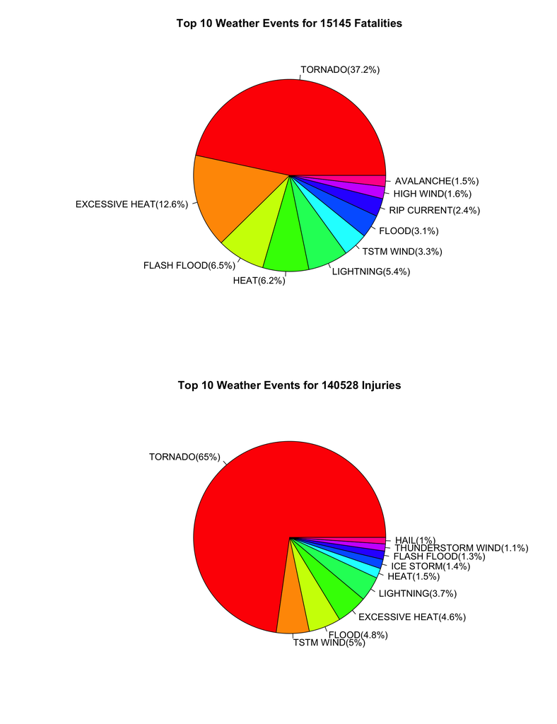

```r
old.par = par(mfrow=c(2, 1))

tryCatch({

    event_labels = paste(
        top_fatalities$EVTYPE,
        "(", round(top_fatalities$FATALITIES/all_fatalities*100, 1), "%)",
        sep=""
    )
    pie(
        top_fatalities$FATALITIES[1:10],
        labels=event_labels[1:10],
        main=sprintf("Top 10 Weather Events for %s Fatalities", all_fatalities),
        col=rainbow(10)
    )
    event_labels = paste(
        top_injuries$EVTYPE,
        "(", round(top_injuries$INJURIES/all_injuries*100, 1), "%)",
        sep=""
    )
    pie(
        top_injuries$INJURIES[1:10],
        labels=event_labels[1:10],
        main=sprintf("Top 10 Weather Events for %s Injuries", all_injuries),
        col=rainbow(10)
    )
}, finally={
    # Reset par values
    par(old.par)
})
```

### Financial Costs

Although the human costs are difficult to fully quantify a dollars and cents, the cost to property owners and farmers is certainly something we can examine in terms of its impact on our economy.

```r
top_property_damage = total_cost_by_event[order(-total_cost_by_event$PROPERTY_DAMAGE)]
all_property_damage = sum(total_cost_by_event$PROPERTY_DAMAGE)
top_crop_damage = total_cost_by_event[order(-total_cost_by_event$CROP_DAMAGE)]
all_crop_damage = sum(total_cost_by_event$CROP_DAMAGE)
```

Our data includes a total of $`10.88` billion in property damage and a total of $`47.57` trillion in crop damage. Here is a table of the top ten most costly weather events in terms of property and crop damage:

#### Most Property Damage due to Weather Events

```r
head(top_property_damage, 10)
```

```
##                 EVTYPE FATALITIES INJURIES PROPERTY_DAMAGE  CROP_DAMAGE
##  1:            TORNADO       5633    91346      3212258160 1.310841e+12
##  2:        FLASH FLOOD        978     1777      1420124590 3.022931e+12
##  3:          TSTM WIND        504     6957      1335965610 1.532824e+12
##  4:              FLOOD        470     6789       899938480 7.124814e+12
##  5:  THUNDERSTORM WIND        133     1488       876844170 1.012830e+12
##  6:               HAIL         15     1361       688693380 8.216322e+12
##  7:          LIGHTNING        816     5230       603351780 4.424090e+10
##  8: THUNDERSTORM WINDS         64      908       446293180 3.564411e+11
##  9:          HIGH WIND        248     1137       324731560 7.885230e+11
## 10:       WINTER STORM        206     1321       132720590 4.453000e+10
```

#### Most Crop Damage due to Weather Events

```r
head(top_crop_damage, 10)
```

```
##                EVTYPE FATALITIES INJURIES PROPERTY_DAMAGE  CROP_DAMAGE
##  1:           DROUGHT          0        4         4099050 1.266558e+13
##  2:              HAIL         15     1361       688693380 8.216322e+12
##  3:             FLOOD        470     6789       899938480 7.124814e+12
##  4:       FLASH FLOOD        978     1777      1420124590 3.022931e+12
##  5:         HURRICANE         61       46        15513680 2.765310e+12
##  6:         TSTM WIND        504     6957      1335965610 1.532824e+12
##  7:      EXTREME COLD        160      231         7657540 1.336470e+12
##  8:           TORNADO       5633    91346      3212258160 1.310841e+12
##  9:      FROST/FREEZE          0        0          968520 1.147600e+12
## 10: HURRICANE/TYPHOON         64     1275         5839370 1.131198e+12
```

#### Visualizing the Financial Costs

These simple pie charts help to illustrate the overwhelming signifigance of a few types of weather events.

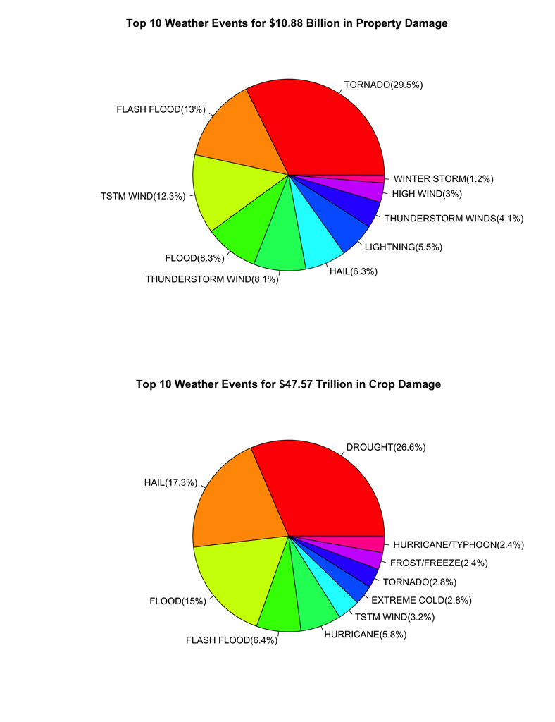

```r
old.par = par(mfrow=c(2, 1))

tryCatch({

    event_labels = paste(
        top_property_damage$EVTYPE,
        "(", round(top_property_damage$PROPERTY_DAMAGE/all_property_damage*100, 1), "%)",
        sep=""
    )
    pie(
        top_property_damage$PROPERTY_DAMAGE[1:10],
        labels=event_labels[1:10],
        main=sprintf(
            "Top 10 Weather Events for $%s Billion in Property Damage ",
            round(all_property_damage/1000000000,2)
        ),
        col=rainbow(10)
    )
    event_labels = paste(
        top_crop_damage$EVTYPE,
        "(", round(top_crop_damage$CROP_DAMAGE/all_crop_damage*100, 1), "%)",
        sep=""
    )
    pie(
        top_crop_damage$CROP_DAMAGE[1:10],
        labels=event_labels[1:10],
        main=sprintf(
            "Top 10 Weather Events for $%s Trillion in Crop Damage",
            round(all_crop_damage/1000000000000,2)
        ),
        col=rainbow(10)
    )
}, finally={
    # Reset par values
    par(old.par)
})
```